# Mini-projet Séries Temporelles TEK-UP 2026 — socle classique en R

Reproduction des phases 1 à 3 (données, analyse exploratoire, ARIMA, VAR, cointégration, GARCH) et comparaison avec Python

2026-11-08

Ce document reproduit en **R** le socle classique du projet (section 3 du cahier des charges, exigée en R **et** en Python, §8.1), ainsi que la préparation des données et l’analyse exploratoire qui le justifient. Les interprétations détaillées se trouvent dans le notebook Python (`notebooks/main_python.ipynb`). L’objet de ce document est de **vérifier que R retrouve les mêmes résultats** et d’**expliquer les écarts**, présentés dans un tableau final.

Exécution : `Rscript -e "rmarkdown::render('notebooks/classical_R.Rmd')"` depuis la racine du projet (packages : `Rscript install_packages.R`).

# 0. Environnement

```r
suppressPackageStartupMessages({
  library(here); library(yaml)
  library(xts); library(zoo); library(quantmod)
  library(forecast); library(tseries); library(urca); library(vars)
  library(lmtest); library(sandwich); library(FinTS); library(rugarch); library(rmgarch)
})
# Seed fixée : seule source d'aléa ici, l'initialisation éventuelle de l'optimiseur de rugarch.
set.seed(42)
# Chemins relatifs à la racine du projet (repérée par le dossier .git) : aucun chemin local en dur.
cfg <- yaml::read_yaml(here("config.yaml"))
pk <- c("quantmod", "xts", "forecast", "tseries", "urca", "vars", "sandwich", "FinTS", "rugarch", "rmgarch", "rmarkdown")
data.frame(package = c("R", pk), version = c(as.character(getRversion()),
                                               vapply(pk, function(p) as.character(packageVersion(p)), "")))
```

|  | package | version |
| --- | --- | --- |
|  | R | 4.6.2 |
| quantmod | quantmod | 0.4.29 |
| xts | xts | 0.14.3 |
| forecast | forecast | 9.0.2 |
| tseries | tseries | 0.10.63 |
| urca | urca | 1.3.4 |
| vars | vars | 1.6.1 |
| sandwich | sandwich | 3.1.3 |
| FinTS | FinTS | 0.4.9 |
| rugarch | rugarch | 1.5.6 |
| rmgarch | rmgarch | 1.4.3 |
| rmarkdown | rmarkdown | 2.32 |

# 1. Données

## 1.1 Lecture du cache et vérification avec quantmod

Pour comparer R et Python **sur des données strictement identiques**, on lit le même cache CSV que Python (`data/raw/`, téléchargé avec `yfinance`). Yahoo recalcule l’Adj Close à chaque dividende : deux téléchargements à des dates différentes ne donneraient pas les mêmes prix. On utilise ensuite `quantmod` pour **vérifier** que Yahoo renvoie bien les mêmes prix aujourd’hui. Le `to` de `getSymbols` exclut la date de fin : on passe donc le lendemain du dernier jour de la période.

```r
read_cache <- function(ticker) {
  f <- here("data", "raw", paste0(gsub("=", "_", ticker), ".csv"))
  d <- read.csv(f, check.names = FALSE)
  xts(d[["Adj Close"]], order.by = as.Date(d$Date))
}
tk <- cfg$data$tickers
xom <- read_cache(tk$target); xle <- read_cache(tk$sector)
# Jointure interne : seuls les jours où les deux actifs cotent (comme en Python).
prices <- merge(xom, xle, join = "inner"); colnames(prices) <- c("XOM", "XLE")
cat(nrow(prices), "jours de bourse, du", format(start(prices)), "au", format(end(prices)), "\n")
```

```
2514 jours de bourse, du 2016-01-04 au 2025-12-31
```

```r
# Vérification indépendante : téléchargement direct via quantmod (le réseau peut manquer, d'où tryCatch).
end_excl <- format(as.Date(cfg$data$end) + 1)
check <- tryCatch({
  q <- getSymbols(tk$target, src = "yahoo", from = cfg$data$start, to = end_excl, auto.assign = FALSE)
  qa <- Ad(q); m <- merge(qa, xom, join = "inner")
  data.frame(`lignes quantmod` = nrow(qa), `lignes cache` = nrow(xom),
             `écart absolu max (USD)` = max(abs(m[, 1] - m[, 2])),
             `écart relatif max` = max(abs(m[, 1] / m[, 2] - 1)), check.names = FALSE)
}, error = function(e) data.frame(`quantmod indisponible` = conditionMessage(e), check.names = FALSE))
check
```

| lignes quantmod | lignes cache | écart absolu max (USD) | écart relatif max |
| --- | --- | --- | --- |
| 2514 | 2514 | 3.81e-05 | 7e-07 |

Résultat : quantmod renvoie 2514 lignes pour 2514 dans le cache, avec un écart relatif maximal de 6.8e-07 sur l’Adj Close. Si cet écart est de l’ordre de l’arrondi, les deux sources sont identiques. S’il est plus grand, Yahoo a réajusté l’historique depuis la constitution du cache (nouveau dividende), ce qui justifie justement de travailler sur le cache figé.

## 1.2 Variables dérivées et découpage 90/10

```r
logp <- log(prices)
ret <- 100 * diff(logp)            # log-rendements en %
vol21 <- sqrt(cfg$features$annualization) * rollapply(ret, cfg$features$realized_vol_window, sd, align = "right")
n <- nrow(prices); n_train <- floor(cfg$split$train_ratio * n)
train_idx <- index(prices)[1:n_train]
test_idx <- index(prices)[(n_train + 1):n]
cat("Train :", n_train, "jours (", format(train_idx[1]), "→", format(tail(train_idx, 1)), ")\n")
```

```
Train : 2262 jours ( 2016-01-04 → 2024-12-27 )
```

```r
cat("Test  :", n - n_train, "jours (", format(test_idx[1]), "→", format(tail(test_idx, 1)), ")\n")
```

```
Test  : 252 jours ( 2024-12-30 → 2025-12-31 )
```

```r
# Séries du train utilisées dans toute la suite (comme en Python : identification sur le train seulement).
L <- logp[train_idx]
r_xom <- as.numeric(na.omit(ret$XOM[train_idx]))
r_xle <- as.numeric(na.omit(ret$XLE[train_idx]))
R <- na.omit(ret[train_idx]); colnames(R) <- c("XOM_ret", "XLE_ret")
```

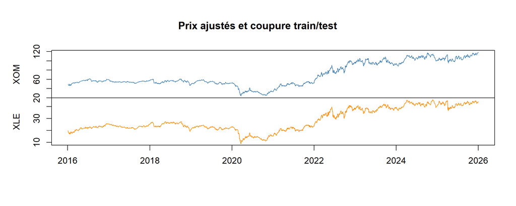

```r
plot.zoo(prices, main = "Prix ajustés et coupure train/test", xlab = "", col = c("steelblue", "darkorange"))
```

# 2. Analyse exploratoire (train)

## 2.1 Statistiques descriptives

```r
moments <- function(x) {
  m <- mean(x); s <- sd(x); z <- (x - m)
  # Skewness et kurtosis « population » (mêmes définitions que scipy, valeurs par défaut).
  sk <- mean(z^3) / mean(z^2)^1.5; ku <- mean(z^4) / mean(z^2)^2 - 3
  c(moyenne = m, ecart_type = s, skewness = sk, exces_kurtosis = ku,
    jarque_bera = unname(jarque.bera.test(x)$statistic))
}
desc <- rbind(XOM = moments(r_xom), XLE = moments(r_xle)); round(desc, 4)
```

```
    moyenne ecart_type skewness exces_kurtosis jarque_bera
XOM  0.0319     1.7845  -0.1630         6.6224    4141.697
XLE  0.0315     1.9216  -0.8902        16.4357   25747.343
```

## 2.2 Autocorrélations

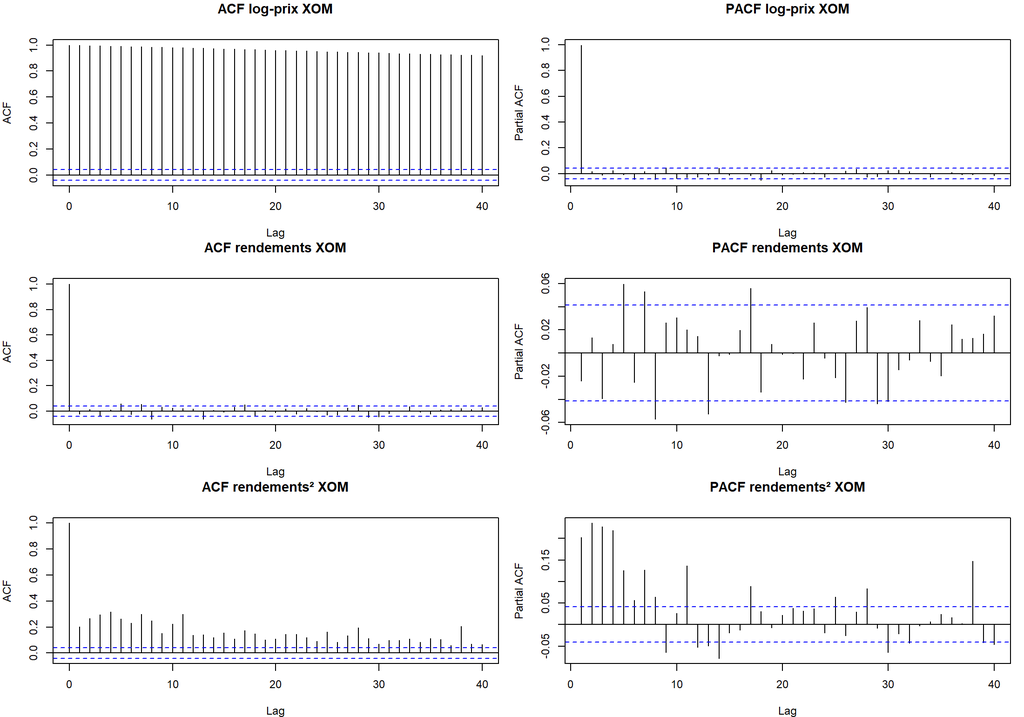

```r
par(mfrow = c(3, 2), mar = c(4, 4, 3, 1))
acf(as.numeric(L$XOM), lag.max = 40, main = "ACF log-prix XOM"); pacf(as.numeric(L$XOM), lag.max = 40, main = "PACF log-prix XOM")
acf(r_xom, lag.max = 40, main = "ACF rendements XOM"); pacf(r_xom, lag.max = 40, main = "PACF rendements XOM")
acf(r_xom^2, lag.max = 40, main = "ACF rendements² XOM"); pacf(r_xom^2, lag.max = 40, main = "PACF rendements² XOM")
```

Même lecture qu’en Python (§2.3) : décroissance très lente pour le log-prix, quasi-bruit blanc pour les rendements, forte autocorrélation des carrés (effets ARCH).

## 2.3 Décomposition STL et force des composantes

```r
# Même réglage que statsmodels : fenêtre saisonnière 7, version robuste.
stl_strength <- function(x, period) {
  s <- stl(ts(as.numeric(x), frequency = period), s.window = 7, robust = TRUE)$time.series
  c(F_T = max(0, 1 - var(s[, "remainder"]) / var(s[, "trend"] + s[, "remainder"])),
    F_S = max(0, 1 - var(s[, "remainder"]) / var(s[, "seasonal"] + s[, "remainder"])))
}
strength <- rbind(`période 5` = stl_strength(L$XOM, 5), `période 252` = stl_strength(L$XOM, 252))
round(strength, 4)
```

```
               F_T F_S
période 5   0.9972   0
période 252 0.8676   0
```

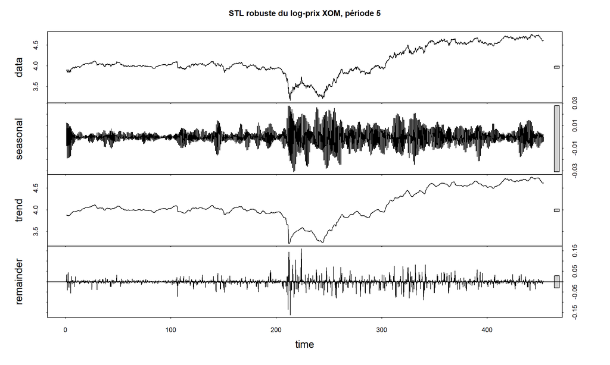

```r
plot(stl(ts(as.numeric(L$XOM), frequency = 5), s.window = 7, robust = TRUE), main = "STL robuste du log-prix XOM, période 5")
```

## 2.4 Valeurs aberrantes (IQR glissant sur les 63 jours précédents, k = 3)

```r
count_outliers <- function(x, w = cfg$features$outlier_window, k = cfg$features$outlier_iqr_k) {
  x <- as.numeric(na.omit(x))
  q1 <- rollapply(x, w, quantile, probs = 0.25, align = "right", fill = NA)
  q3 <- rollapply(x, w, quantile, probs = 0.75, align = "right", fill = NA)
  q1 <- c(NA, head(q1, -1)); q3 <- c(NA, head(q3, -1))   # décalage d'un jour : seuil calculé sur le passé
  iqr <- q3 - q1
  sum((x < q1 - k * iqr) | (x > q3 + k * iqr), na.rm = TRUE)
}
c(XOM = count_outliers(ret$XOM), XLE = count_outliers(ret$XLE))
```

```
XOM XLE
 15  18
```

## 2.5 Stationnarité : ADF, KPSS, Zivot-Andrews

`urca` ne fournit pas de p-values pour ADF et KPSS, seulement des valeurs critiques. Pour comparer les **statistiques** à Python, on impose les mêmes nombres de retards : ADF avec choix par AIC jusqu’à ⌈12 (n/100)^(1/4)⌉ = 27 retards, comme `statsmodels` ; KPSS avec le nombre de retards trouvé par `statsmodels`, puis avec la règle par défaut de `urca`.

```r
py <- read.csv(here("outputs", "tables", "tab29_reference_python.csv"), check.names = FALSE)
# La colonne mélange nombres et textes (dates, noms de modèles) : conversion explicite des nombres.
pyv <- setNames(suppressWarnings(as.numeric(py$valeur_python)), py$clé)
maxlag <- ceiling(12 * (n_train / 100)^(1 / 4))
adf <- function(x, type) {
  t <- ur.df(as.numeric(x), type = type, lags = maxlag, selectlags = "AIC")
  # Nombre de retards retenus = lignes de la régression de test moins constante, niveau retardé et tendance.
  c(stat = unname(t@teststat[1]), retards = nrow(t@testreg$coefficients) - 1 - (type != "none") - (type == "trend"),
    VC5 = unname(t@cval[1, "5pct"]))
}
kpss <- function(x, type, lag) {
  t <- ur.kpss(as.numeric(x), type = type, use.lag = lag)
  c(stat = unname(t@teststat), VC5 = unname(t@cval[1, "5pct"]))
}
stat_tab <- rbind(
  `ADF log-prix, constante` = adf(L$XOM, "drift"),
  `ADF log-prix, constante + tendance` = adf(L$XOM, "trend"),
  `ADF rendement, constante` = adf(r_xom, "drift"))
kpss_tab <- rbind(
  `KPSS log-prix, constante (retards Python)` = c(kpss(L$XOM, "mu", pyv[["kpss_lags_XOM_logprix_c"]]), retards = pyv[["kpss_lags_XOM_logprix_c"]]),
  `KPSS log-prix, tendance (retards Python)` = c(kpss(L$XOM, "tau", pyv[["kpss_lags_XOM_logprix_ct"]]), retards = pyv[["kpss_lags_XOM_logprix_ct"]]),
  `KPSS rendement, constante (retards Python)` = c(kpss(r_xom, "mu", pyv[["kpss_lags_XOM_rendement_c"]]), retards = pyv[["kpss_lags_XOM_rendement_c"]]),
  `KPSS log-prix, constante (règle urca « long »)` = {t <- ur.kpss(as.numeric(L$XOM), type = "mu", lags = "long"); c(stat = t@teststat, VC5 = t@cval[1, "5pct"], retards = t@lag)})
round(stat_tab, 4); round(kpss_tab, 4)
```

```
                                       stat retards   VC5
ADF log-prix, constante             -0.9479      18 -2.86
ADF log-prix, constante + tendance  -1.6179      18 -3.41
ADF rendement, constante           -10.5484      17 -2.86
```

```
                                                 stat   VC5 retards
KPSS log-prix, constante (retards Python)      3.5632 0.463      29
KPSS log-prix, tendance (retards Python)       1.3972 0.146      29
KPSS rendement, constante (retards Python)     0.1439 0.463       8
KPSS log-prix, constante (règle urca « long ») 3.9510 0.463      26
```

```r
za <- function(x, model, lag) {
  t <- ur.za(as.numeric(x), model = model, lag = lag)
  c(stat = unname(t@teststat), VC5 = unname(t@cval[2]), rupture = as.numeric(index(x)[t@bpoint]))
}
za_tab <- rbind(`rupture de niveau` = za(L$XOM, "intercept", pyv[["za_lags_c"]]),
                `rupture de niveau et de pente` = za(L$XOM, "both", pyv[["za_lags_ct"]]))
data.frame(statistique = round(za_tab[, "stat"], 4), `VC 5 %` = za_tab[, "VC5"],
           `date de rupture` = as.Date(za_tab[, "rupture"]), check.names = FALSE)
```

|  | statistique | VC 5 % | date de rupture |
| --- | --- | --- | --- |
| rupture de niveau | -3.7940 | -4.80 | 2021-12-20 |
| rupture de niveau et de pente | -4.2081 | -5.08 | 2020-01-06 |

Conclusion identique à Python : log-prix I(1), rendements I(0), donc **d = 1**.

# 3. Modélisation classique

## 3.1 ARIMA et SARIMA (`forecast`)

Comme en Python, un ARIMA(p,1,q) du log-prix est estimé sous la forme ARMA(p,q) des rendements en %, par maximum de vraisemblance exacte.

```r
fit_arma <- function(p, q, mean = FALSE) Arima(r_xom, order = c(p, 0, q), include.mean = mean, method = "ML")
cands <- list(`ARIMA(0,1,0)` = fit_arma(0, 0), `ARIMA(1,1,0)` = fit_arma(1, 0), `ARIMA(0,1,1)` = fit_arma(0, 1),
              `ARIMA(1,1,1)` = fit_arma(1, 1), `ARIMA(0,1,0) + dérive` = fit_arma(0, 0, TRUE), `ARIMA(3,1,2)` = fit_arma(3, 2))
arima_tab <- data.frame(`log-vraisemblance` = sapply(cands, logLik), AIC = sapply(cands, AIC), BIC = sapply(cands, BIC),
                        check.names = FALSE)
arima_tab[order(arima_tab$AIC), ]
```

|  | log-vraisemblance | AIC | BIC |
| --- | --- | --- | --- |
| ARIMA(3,1,2) | -4511.124 | 9034.249 | 9068.590 |
| ARIMA(0,1,0) | -4517.551 | 9037.103 | 9042.826 |
| ARIMA(1,1,0) | -4516.920 | 9037.839 | 9049.286 |
| ARIMA(0,1,1) | -4516.936 | 9037.871 | 9049.318 |
| ARIMA(0,1,0) + dérive | -4517.191 | 9038.382 | 9049.829 |
| ARIMA(1,1,1) | -4516.456 | 9038.911 | 9056.082 |

```r
# Recherche exhaustive, sans approximation, d = 0 sur les rendements (d = 1 sur le log-prix, établi en §2).
auto <- lapply(c(aic = "aic", bic = "bic"), function(ic)
  auto.arima(r_xom, d = 0, D = 0, max.p = 5, max.q = 5, max.order = 5, seasonal = FALSE,
             stepwise = FALSE, approximation = FALSE, ic = ic, allowmean = TRUE, allowdrift = FALSE))
auto_lab <- sapply(auto, function(m) { o <- arimaorder(m); sprintf("ARIMA(%d,1,%d)", o[["p"]], o[["q"]]) })
auto_lab
```

```
           aic            bic
"ARIMA(5,1,0)" "ARIMA(0,1,0)"
```

```r
sapply(auto, function(m) c(AIC = m$aic, BIC = m$bic, constante = "intercept" %in% names(coef(m))))
```

```
               aic      bic
AIC       9033.741 9037.103
BIC       9068.082 9042.826
constante    0.000    0.000
```

```r
sar <- Arima(r_xom, order = c(0, 0, 0), seasonal = list(order = c(1, 0, 0), period = 5), include.mean = FALSE, method = "ML")
c(`coefficient SAR(1)[5]` = unname(coef(sar)["sar1"]), `ΔAIC vs (0,1,0)` = AIC(sar) - AIC(cands$`ARIMA(0,1,0)`))
```

```
coefficient SAR(1)[5]       ΔAIC vs (0,1,0)
           0.05816995           -5.66963351
```

```r
# Diagnostic complet de la marche aléatoire : Ljung-Box (ddl corrigés de p + q = 0), Jarque-Bera, ARCH-LM.
e_rw <- residuals(cands$`ARIMA(0,1,0)`)
rw_diag <- c(`Ljung-Box Q(10)` = unname(Box.test(e_rw, lag = 10, type = "Ljung-Box", fitdf = 0)$statistic),
             `Jarque-Bera` = unname(jarque.bera.test(e_rw)$statistic),
             `ARCH-LM(5)` = unname(ArchTest(e_rw, lags = 5)$statistic))
round(rw_diag, 3)
```

```
Ljung-Box Q(10)     Jarque-Bera      ARCH-LM(5)
         34.900        4141.697         441.168
```

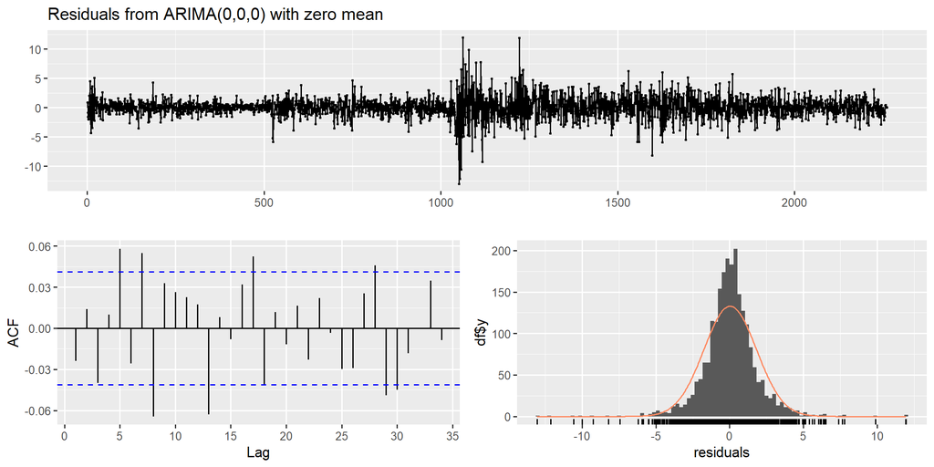

```r
checkresiduals(cands$`ARIMA(0,1,0)`, test = FALSE)
```

Décision identique à Python : **ARIMA(0,1,0)** retenu (choix du BIC), ARIMA(3,1,2) (choix de l’AIC) gardé comme concurrent, SARIMA s = 5 écarté.

## 3.2 VAR, causalité de Granger, cointégration (`vars`, `urca`)

```r
sel <- VARselect(R, lag.max = 10, type = "const")$selection; sel
```

```
AIC(n)  HQ(n)  SC(n) FPE(n)
     9      7      1      9
```

```r
v1 <- VAR(R, p = 1, type = "const")
A1 <- Acoef(v1)[[1]]; round(A1, 4)
```

```
        XOM_ret.l1 XLE_ret.l1
XOM_ret     0.1010    -0.1268
XLE_ret     0.1046    -0.1344
```

```r
c(`stable (module max)` = max(roots(v1)),
  `Portmanteau ajusté h = 10` = unname(serial.test(v1, lags.pt = 10, type = "PT.adjusted")$serial$statistic))
```

```
      stable (module max) Portmanteau ajusté h = 10
               0.04106908              166.14447142
```

```r
# F classique, puis Wald robuste à l'hétéroscédasticité (matrice HC3 de sandwich).
g <- function(cause, vc = NULL) causality(v1, cause = cause, vcov. = vc)$Granger$p.value[1, 1]
c(`XLE → XOM, classique` = g("XLE_ret"), `XLE → XOM, HC3` = g("XLE_ret", vcovHC(v1)),
  `XOM → XLE, classique` = g("XOM_ret"))
```

```
XLE → XOM, classique       XLE → XOM, HC3 XOM → XLE, classique
         0.008910848          0.195383497          0.062679799
```

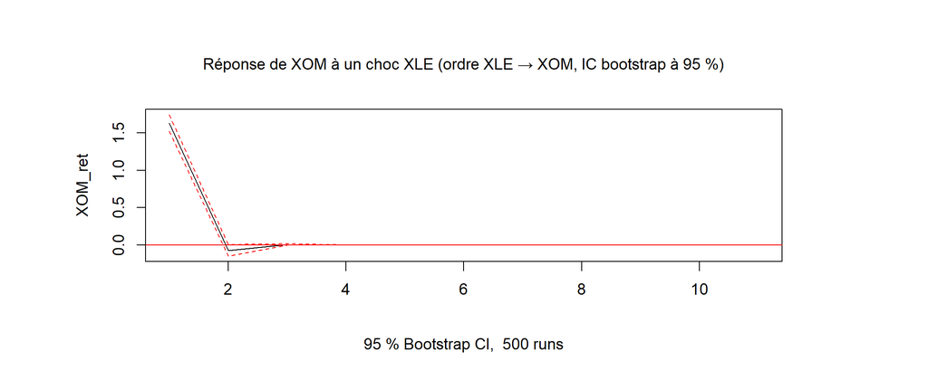

```r
# IRF orthogonalisées et FEVD : dans vars, l'ordre de Cholesky est l'ordre des colonnes.
# On place XLE en premier (choc sectoriel → XOM le jour même), puis on inverse pour la robustesse.
v_xle_first <- VAR(R[, c("XLE_ret", "XOM_ret")], p = 1, type = "const")
v_xom_first <- VAR(R[, c("XOM_ret", "XLE_ret")], p = 1, type = "const")
irf_r <- irf(v_xle_first, impulse = "XLE_ret", response = "XOM_ret", n.ahead = 10, ortho = TRUE,
             boot = TRUE, runs = 500, ci = 0.95)
plot(irf_r, main = "Réponse de XOM à un choc XLE (ordre XLE → XOM, IC bootstrap à 95 %)")
```

```r
fevd_tab <- rbind(`XLE → XOM : part de XLE dans la variance de XOM` = fevd(v_xle_first, n.ahead = 10)$XOM_ret[c(1, 5, 10), "XLE_ret"],
                  `XOM → XLE : part de XLE dans la variance de XOM` = fevd(v_xom_first, n.ahead = 10)$XOM_ret[c(1, 5, 10), "XLE_ret"])
colnames(fevd_tab) <- c("h = 1", "h = 5", "h = 10")
round(fevd_tab, 4)
```

```
                                                 h = 1  h = 5 h = 10
XLE → XOM : part de XLE dans la variance de XOM 0.8373 0.8362 0.8362
XOM → XLE : part de XLE dans la variance de XOM 0.0000 0.0030 0.0030
```

Même lecture qu’en Python (§3.2.6) : la réponse est entièrement concentrée sur le jour 0 et nulle dès le 2ᵉ jour, quel que soit l’ordre. La FEVD, en revanche, dépend entièrement de l’ordre de Cholesky (≈ 84 % ou ≈ 0 %), car elle ne fait qu’attribuer la corrélation contemporaine des chocs (0,915² ≈ 0,84) à la variable placée en premier.

```r
# Engle-Granger : régression de long terme puis ADF sans constante sur le résidu (même procédure que statsmodels.coint).
u <- residuals(lm(as.numeric(L$XOM) ~ as.numeric(L$XLE)))
eg <- ur.df(u, type = "none", lags = maxlag, selectlags = "AIC")@teststat[1]
c(`Engle-Granger (stat.)` = eg)
```

```
Engle-Granger (stat.)
            -4.407115
```

```r
# Johansen : K = retards en niveaux = retards en différences + 1. urca impose K ≥ 2.
joh <- function(K, type) {
  t <- ca.jo(coredata(L), ecdet = "none", type = type, K = K, spec = "transitory")
  unname(t@teststat[length(t@teststat)])          # dernière valeur = H0 : r = 0
}
joh_tab <- sapply(c(`k = 1 (K = 2)` = 2, `k = 6 (K = 7)` = 7, `k = 8 (K = 9)` = 9),
                  function(K) c(trace = joh(K, "trace"), lambda_max = joh(K, "eigen")))
round(joh_tab, 3)
```

```
           k = 1 (K = 2) k = 6 (K = 7) k = 8 (K = 9)
trace             14.457        15.800        21.625
lambda_max        13.675        15.133        21.139
```

```r
ca.jo(coredata(L), ecdet = "none", type = "trace", K = 2, spec = "transitory")@cval
```

```
         10pct  5pct  1pct
r <= 1 |  6.50  8.18 11.65
r = 0  | 15.66 17.95 23.52
```

```r
# VECM à constante restreinte, r = 1, K = 2 (k = 1) : le plus petit modèle permis par urca.
cj <- ca.jo(coredata(L), ecdet = "const", type = "trace", K = 2, spec = "transitory")
vecm <- cajorls(cj, r = 1)
beta <- vecm$beta[, 1]; alpha <- coef(vecm$rlm)["ect1", ]
speed <- sum(beta[1:2] * alpha)
round(c(beta_XLE = beta[[2]], constante = beta[[3]], alpha_XOM = alpha[[1]], alpha_XLE = alpha[[2]],
        `β'α` = speed, `demi-vie (jours)` = log(0.5) / log(1 + speed)), 5)
```

```
        beta_XLE        constante        alpha_XOM        alpha_XLE
        -1.12516         -0.46355         -0.00206          0.00781
             β'α demi-vie (jours)
        -0.01085         63.56554
```

## 3.3 GARCH (`rugarch`)

Moyenne nulle (marche aléatoire sans dérive), comme en Python.

```r
spec <- function(model, dist) ugarchspec(variance.model = list(model = model, garchOrder = c(1, 1)),
                                         mean.model = list(armaOrder = c(0, 0), include.mean = FALSE),
                                         distribution.model = dist)
fits <- list(garch11_n = ugarchfit(spec("sGARCH", "norm"), r_xom, solver = "hybrid"),
             garch11_t = ugarchfit(spec("sGARCH", "std"), r_xom, solver = "hybrid"),
             gjr11_t = ugarchfit(spec("gjrGARCH", "std"), r_xom, solver = "hybrid"))
garch_tab <- t(sapply(fits, function(f) {
  cf <- coef(f)
  c(llf = likelihood(f), omega = cf[["omega"]], alpha = cf[["alpha1"]],
    gamma = if ("gamma1" %in% names(cf)) cf[["gamma1"]] else NA, beta = cf[["beta1"]],
    nu = if ("shape" %in% names(cf)) cf[["shape"]] else NA, persistance = persistence(f))
}))
round(garch_tab, 4)
```

```
                llf  omega  alpha  gamma   beta     nu persistance
garch11_n -4083.064 0.0146 0.0766     NA 0.9208     NA      0.9974
garch11_t -4045.620 0.0102 0.0685     NA 0.9305 7.3316      0.9990
gjr11_t   -4041.492 0.0095 0.0423 0.0418 0.9358 7.5382      0.9990
```

```r
gjr <- fits$gjr11_t
z <- as.numeric(residuals(gjr, standardize = TRUE)); nu <- coef(gjr)[["shape"]]
c(`Ljung-Box z (10), p` = Box.test(z, 10, "Ljung-Box")$p.value,
  `Ljung-Box z² (10), p` = Box.test(z^2, 10, "Ljung-Box")$p.value,
  `ARCH-LM(5) sur z` = unname(ArchTest(z, lags = 5)$statistic),
  `KS contre la Student, p` = ks.test(z, function(q) pdist("std", q, mu = 0, sigma = 1, shape = nu))$p.value)
```

```
    Ljung-Box z (10), p    Ljung-Box z² (10), p        ARCH-LM(5) sur z
             0.97350235              0.04097683             14.48025829
KS contre la Student, p
             0.44668502
```

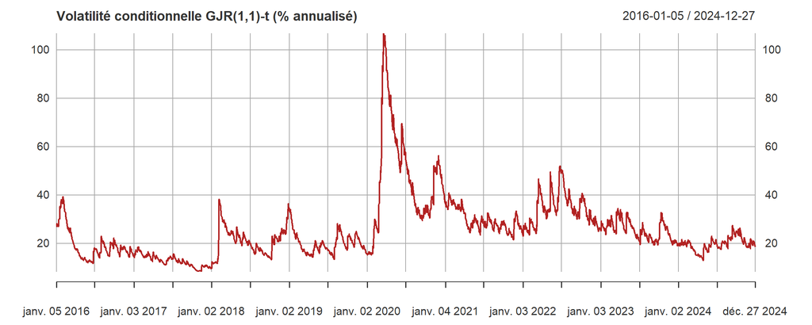

```r
plot(xts(sigma(gjr) * sqrt(252), order.by = index(R)), main = "Volatilité conditionnelle GJR(1,1)-t (% annualisé)", col = "firebrick")
```

# 4. Comparaison R / Python

```r
r_vals <- list(
  n_jours = n, n_train = n_train, n_test = n - n_train, debut_test = format(test_idx[1]),
  XOM_moyenne = desc["XOM", "moyenne"], XOM_ecart_type = desc["XOM", "ecart_type"], XOM_skewness = desc["XOM", "skewness"],
  XOM_exces_kurtosis = desc["XOM", "exces_kurtosis"], XOM_jarque_bera = desc["XOM", "jarque_bera"],
  XLE_skewness = desc["XLE", "skewness"], XLE_exces_kurtosis = desc["XLE", "exces_kurtosis"],
  XOM_nb_outliers = count_outliers(ret$XOM), XLE_nb_outliers = count_outliers(ret$XLE),
  stl_FS_p5 = strength["période 5", "F_S"], stl_FT_p5 = strength["période 5", "F_T"], stl_FT_p252 = strength["période 252", "F_T"],
  adf_stat_XOM_logprix_c = stat_tab[1, "stat"], adf_lags_XOM_logprix_c = stat_tab[1, "retards"],
  adf_stat_XOM_logprix_ct = stat_tab[2, "stat"], adf_stat_XOM_rendement_c = stat_tab[3, "stat"],
  adf_lags_XOM_rendement_c = stat_tab[3, "retards"],
  kpss_stat_XOM_logprix_c = kpss_tab[1, "stat"], kpss_stat_XOM_logprix_ct = kpss_tab[2, "stat"],
  kpss_stat_XOM_rendement_c = kpss_tab[3, "stat"],
  za_stat_c = za_tab[1, "stat"], za_stat_ct = za_tab[2, "stat"],
  za_date_c = format(as.Date(za_tab[1, "rupture"])), za_date_ct = format(as.Date(za_tab[2, "rupture"])),
  `aic_ARIMA(0,1,0)` = AIC(cands$`ARIMA(0,1,0)`), `aic_ARIMA(1,1,0)` = AIC(cands$`ARIMA(1,1,0)`),
  `aic_ARIMA(0,1,1)` = AIC(cands$`ARIMA(0,1,1)`), `aic_ARIMA(1,1,1)` = AIC(cands$`ARIMA(1,1,1)`),
  `aic_ARIMA(0,1,0) + dérive` = AIC(cands$`ARIMA(0,1,0) + dérive`), `aic_ARIMA(3,1,2)` = AIC(cands$`ARIMA(3,1,2)`),
  `llf_ARIMA(3,1,2)` = as.numeric(logLik(cands$`ARIMA(3,1,2)`)),
  `ar1_ARIMA(1,1,0)` = coef(cands$`ARIMA(1,1,0)`)[["ar1"]],
  `derive_ARIMA(0,1,0)` = coef(cands$`ARIMA(0,1,0) + dérive`)[["intercept"]],
  auto_arima_aic = auto_lab[["aic"]], auto_arima_bic = auto_lab[["bic"]],
  rw_ljungbox_10 = rw_diag[["Ljung-Box Q(10)"]], rw_jarque_bera = rw_diag[["Jarque-Bera"]], rw_archlm_5 = rw_diag[["ARCH-LM(5)"]],
  sar5_coef = coef(sar)[["sar1"]], sar5_delta_aic = AIC(sar) - AIC(cands$`ARIMA(0,1,0)`),
  var_ordre_AIC = sel[["AIC(n)"]], var_ordre_BIC = sel[["SC(n)"]], var_ordre_HQIC = sel[["HQ(n)"]], var_ordre_FPE = sel[["FPE(n)"]],
  # Acoef : ligne = équation, colonne = variable retardée (ordre XOM, XLE).
  `var1_XOM_ret_L1.XOM_ret` = A1[1, 1], `var1_XOM_ret_L1.XLE_ret` = A1[1, 2],
  `var1_XLE_ret_L1.XOM_ret` = A1[2, 1], `var1_XLE_ret_L1.XLE_ret` = A1[2, 2],
  var1_portmanteau_10 = unname(serial.test(v1, lags.pt = 10, type = "PT.adjusted")$serial$statistic),
  granger_p1_XLE_XOM_classique = g("XLE_ret"), granger_p1_XLE_XOM_HC3 = g("XLE_ret", vcovHC(v1)),
  granger_p1_XOM_XLE_classique = g("XOM_ret"),
  eg_stat_XOM_sur_XLE = eg,
  irf_xom_choc_xle_h0 = irf(v_xle_first, impulse = "XLE_ret", response = "XOM_ret", n.ahead = 10, ortho = TRUE, boot = FALSE)$irf$XLE_ret[1, "XOM_ret"],
  irf_xom_choc_xle_h1 = irf(v_xle_first, impulse = "XLE_ret", response = "XOM_ret", n.ahead = 10, ortho = TRUE, boot = FALSE)$irf$XLE_ret[2, "XOM_ret"],
  fevd_xom_part_xle_h10 = fevd(v_xle_first, n.ahead = 10)$XOM_ret[10, "XLE_ret"],
  `johansen_trace_k=1` = joh_tab["trace", 1], `johansen_lmax_k=1` = joh_tab["lambda_max", 1],
  `johansen_trace_k=6` = joh_tab["trace", 2], `johansen_lmax_k=6` = joh_tab["lambda_max", 2],
  `johansen_trace_k=8` = joh_tab["trace", 3], `johansen_lmax_k=8` = joh_tab["lambda_max", 3],
  vecm_k1_beta_XLE = beta[[2]], vecm_k1_const = beta[[3]], vecm_k1_alpha_XOM = alpha[[1]], vecm_k1_alpha_XLE = alpha[[2]],
  vecm_k1_demi_vie = log(0.5) / log(1 + speed),
  garch11_n_llf = garch_tab["garch11_n", "llf"], garch11_n_omega = garch_tab["garch11_n", "omega"],
  `garch11_n_alpha[1]` = garch_tab["garch11_n", "alpha"], `garch11_n_beta[1]` = garch_tab["garch11_n", "beta"],
  garch11_n_persistance = garch_tab["garch11_n", "persistance"],
  garch11_t_llf = garch_tab["garch11_t", "llf"], garch11_t_omega = garch_tab["garch11_t", "omega"],
  `garch11_t_alpha[1]` = garch_tab["garch11_t", "alpha"], `garch11_t_beta[1]` = garch_tab["garch11_t", "beta"],
  garch11_t_nu = garch_tab["garch11_t", "nu"], garch11_t_persistance = garch_tab["garch11_t", "persistance"],
  gjr11_t_llf = garch_tab["gjr11_t", "llf"], gjr11_t_omega = garch_tab["gjr11_t", "omega"],
  `gjr11_t_alpha[1]` = garch_tab["gjr11_t", "alpha"], `gjr11_t_gamma[1]` = garch_tab["gjr11_t", "gamma"],
  `gjr11_t_beta[1]` = garch_tab["gjr11_t", "beta"], gjr11_t_nu = garch_tab["gjr11_t", "nu"],
  gjr11_t_persistance = garch_tab["gjr11_t", "persistance"],
  gjr11_t_archlm5_z = unname(ArchTest(z, lags = 5)$statistic),
  gjr11_t_ks_p = ks.test(z, function(q) pdist("std", q, mu = 0, sigma = 1, shape = nu))$p.value)

cmp <- merge(py, data.frame(clé = names(r_vals), valeur_r = vapply(r_vals, function(v) as.character(v), "")),
             by = "clé", sort = FALSE)
num_py <- suppressWarnings(as.numeric(cmp$valeur_python)); num_r <- suppressWarnings(as.numeric(cmp$valeur_r))
cmp$`écart relatif` <- ifelse(is.na(num_py) | is.na(num_r), NA, abs(num_r - num_py) / pmax(abs(num_py), 1e-8))
cmp$verdict <- ifelse(is.na(cmp$`écart relatif`), ifelse(cmp$valeur_python == cmp$valeur_r, "identique", "DIFFÉRENT"),
               ifelse(cmp$`écart relatif` < 1e-3, "identique (< 0,1 %)",
               ifelse(cmp$`écart relatif` < 0.02, "très proche (< 2 %)", "écart notable")))
fmt <- function(v) ifelse(is.na(suppressWarnings(as.numeric(v))), v, formatC(as.numeric(v), digits = 5, format = "g"))
cmp_out <- data.frame(grandeur = cmp$description, Python = fmt(cmp$valeur_python), R = fmt(cmp$valeur_r),
                      `écart relatif` = ifelse(is.na(cmp$`écart relatif`), "", sprintf("%.2g", cmp$`écart relatif`)),
                      verdict = cmp$verdict, check.names = FALSE)
# Connexion binaire : sous Windows, une connexion texte convertit "\n" en "\r\n" même avec eol = "\n",
# ce qui ferait apparaître le fichier comme modifié dans git à chaque rendu.
con <- file(here("outputs", "tables", "tab30_comparaison_R_python.csv"), open = "wb", encoding = "UTF-8")
write.csv(cbind(clé = cmp$clé, cmp_out), con, row.names = FALSE, eol = "\n")
close(con)
table(cmp$verdict)
```

```
          DIFFÉRENT       écart notable           identique identique (< 0,1 %)
                  1                   5                   4                  67
très proche (< 2 %)
                 14
```

```r
cmp_out
```

| grandeur | Python | R | écart relatif | verdict |
| --- | --- | --- | --- | --- |
| jours de bourse XOM/XLE | 2514 | 2514 | 0 | identique (< 0,1 %) |
| jours du train | 2262 | 2262 | 0 | identique (< 0,1 %) |
| jours du test | 252 | 252 | 0 | identique (< 0,1 %) |
| premier jour du test | 2024-12-30 | 2024-12-30 |  | identique |
| moyenne des rendements XOM (train) | 0.031852 | 0.031852 | 1.5e-15 | identique (< 0,1 %) |
| écart-type des rendements XOM (train) | 1.7845 | 1.7845 | 1.5e-15 | identique (< 0,1 %) |
| skewness des rendements XOM (train) | -0.16304 | -0.16304 | 1.4e-15 | identique (< 0,1 %) |
| excès de kurtosis des rendements XOM (train) | 6.6224 | 6.6224 | 0 | identique (< 0,1 %) |
| Jarque-Bera des rendements XOM (train) | 4141.7 | 4141.7 | 1.5e-15 | identique (< 0,1 %) |
| skewness des rendements XLE (train) | -0.89016 | -0.89016 | 5e-16 | identique (< 0,1 %) |
| excès de kurtosis des rendements XLE (train) | 16.436 | 16.436 | 1.9e-15 | identique (< 0,1 %) |
| jours extrêmes XOM (IQR 63 j, k = 3) | 15 | 15 | 0 | identique (< 0,1 %) |
| jours extrêmes XLE (IQR 63 j, k = 3) | 18 | 18 | 0 | identique (< 0,1 %) |
| force de saisonnalité STL, période 5 (XOM) | 0 | 0 | 0 | identique (< 0,1 %) |
| force de tendance STL, période 5 (XOM) | 0.99678 | 0.99721 | 0.00043 | identique (< 0,1 %) |
| force de tendance STL, période 252 (XOM) | 0.8686 | 0.86763 | 0.0011 | très proche (< 2 %) |
| ADF XOM log-prix, constante | -0.97142 | -0.94791 | 0.024 | écart notable |
| retards ADF (AIC) XOM log-prix, constante | 18 | 18 | 0 | identique (< 0,1 %) |
| KPSS XOM log-prix, constante | 3.5632 | 3.5632 | 5e-16 | identique (< 0,1 %) |
| ADF XOM log-prix, constante + tendance | -1.5995 | -1.6179 | 0.011 | très proche (< 2 %) |
| KPSS XOM log-prix, constante + tendance | 1.3972 | 1.3972 | 7.9e-15 | identique (< 0,1 %) |
| ADF XOM rendement, constante | -10.557 | -10.548 | 0.00078 | identique (< 0,1 %) |
| retards ADF (AIC) XOM rendement, constante | 17 | 17 | 0 | identique (< 0,1 %) |
| KPSS XOM rendement, constante | 0.14387 | 0.14387 | 3.5e-15 | identique (< 0,1 %) |
| Zivot-Andrews XOM log-prix, rupture de niveau | -3.794 | -3.794 | 7e-13 | identique (< 0,1 %) |
| date de rupture Zivot-Andrews, rupture de niveau | 2021-12-20 | 2021-12-20 |  | identique |
| Zivot-Andrews XOM log-prix, rupture de niveau et de pente | -4.2081 | -4.2081 | 1.1e-12 | identique (< 0,1 %) |
| date de rupture Zivot-Andrews, rupture de niveau et de pente | 2020-01-06 | 2020-01-06 |  | identique |
| AIC ARIMA(0,1,0) | 9037.1 | 9037.1 | 0 | identique (< 0,1 %) |
| AIC ARIMA(1,1,0) | 9037.8 | 9037.8 | 4.8e-12 | identique (< 0,1 %) |

[output cut: 61 more lines]

## 4.1 Vérification des écarts

Chaque écart notable est reproduit ci-dessous dans des conditions identiques à Python, pour en établir la cause plutôt que la supposer.

```r
verif <- list()
# (1) ADF : même nombre de retards (18) imposé, sans sélection.
verif$`ADF log-prix, 18 retards imposés` <- ur.df(as.numeric(L$XOM), "drift", lags = 18)@teststat[1]
# (2) Engle-Granger : même nombre de retards que statsmodels (19) imposé.
verif$`Engle-Granger, 19 retards imposés` <- ur.df(u, type = "none", lags = 19)@teststat[1]
# (3) ARIMA(3,1,2) démarré aux coefficients trouvés par Python (sans reparamétrisation, trop proche de la frontière).
f312 <- Arima(r_xom, order = c(3, 0, 2), include.mean = FALSE, method = "ML", transform.pars = FALSE,
              init = c(-1.6595, -0.8521, 0.0319, 1.6453, 0.8656))
verif$`ARIMA(3,1,2), départ Python : log-vraisemblance` <- as.numeric(logLik(f312))
verif$`ARIMA(3,1,2), départ par défaut de R : log-vraisemblance` <- as.numeric(logLik(cands$`ARIMA(3,1,2)`))
verif$`ARIMA(5,1,0), choix de auto.arima : AIC` <- AIC(Arima(r_xom, order = c(5, 0, 0), include.mean = FALSE, method = "ML"))
# (4) VARselect : ordres effectivement testés.
verif$`VARselect : plus petit ordre testé` <- min(as.numeric(colnames(VARselect(R, lag.max = 10, type = "const")$criteria)))
# (5) GARCH : vraisemblance de rugarch évaluée aux paramètres exacts de Python.
sp_fix <- ugarchspec(variance.model = list(model = "sGARCH", garchOrder = c(1, 1)),
                     mean.model = list(armaOrder = c(0, 0), include.mean = FALSE), distribution.model = "std",
                     fixed.pars = list(omega = pyv[["garch11_t_omega"]], alpha1 = pyv[["garch11_t_alpha[1]"]],
                                       beta1 = pyv[["garch11_t_beta[1]"]], shape = pyv[["garch11_t_nu"]]))
verif$`GARCH(1,1)-t aux paramètres Python, filtre rugarch : log-vraisemblance` <- likelihood(ugarchfilter(sp_fix, r_xom))
verif$`variance initiale de rugarch (moyenne des r²)` <- mean(r_xom^2)
data.frame(vérification = names(verif), valeur = round(unlist(verif), 4), row.names = NULL)
```

| vérification | valeur |
| --- | --- |
| ADF log-prix, 18 retards imposés | -0.9714 |
| Engle-Granger, 19 retards imposés | -3.4565 |
| ARIMA(3,1,2), départ Python : log-vraisemblance | -4504.6315 |
| ARIMA(3,1,2), départ par défaut de R : log-vraisemblance | -4511.1243 |
| ARIMA(5,1,0), choix de auto.arima : AIC | 9033.7410 |
| VARselect : plus petit ordre testé | 1.0000 |
| GARCH(1,1)-t aux paramètres Python, filtre rugarch : log-vraisemblance | -4045.6214 |
| variance initiale de rugarch (moyenne des r²) | 3.1842 |

## 4.2 Explication des écarts

**Bilan.** Sur 91 grandeurs comparées, 71 sont identiques (écart relatif < 0,1 %) et 14 très proches (< 2 %). **Aucune conclusion du projet ne change entre R et Python.** Les données, le découpage, les statistiques descriptives, les valeurs aberrantes, KPSS, Zivot-Andrews, les ARIMA de petit ordre, le SARIMA, les coefficients du VAR(1), le Portmanteau, Johansen et le VECM coïncident à la précision numérique près.

Les écarts restants ont tous une cause identifiée et vérifiée :

| Écart | Cause | Preuve |
| --- | --- | --- |
| **ADF du log-prix** : −0,948 en R contre −0,971 en Python, avec le même nombre de retards (18) | `urca` estime le modèle retenu sur l’échantillon raccourci par le retard **maximal** testé (27). `statsmodels` le ré-estime sur l’échantillon le plus long permis par le retard **choisi** (18), soit 9 … | Avec 18 retards imposés, R donne −0,9714, comme Python. Conclusion identique : racine unitaire non rejetée (valeur critique à 5 % : −2,86). |
| **Engle-Granger** : −4,41 en R contre −3,46 en Python, avec le même nombre de retards (19) | Même cause que pour l’ADF. Ici l’effet est grand, parce que les 8 observations en plus ou en moins tombent en janvier 2016, quand l’écart à l’équilibre était au plus haut (figure 11 du notebook Python… | Avec 19 retards imposés, R donne −3,4565, comme Python. Les deux statistiques dépassent la valeur critique à 5 % (−3,34). L’écart montre surtout que ce test est **sensible aux toutes premières observa… |
| **ARIMA(3,1,2)** : log-vraisemblance −4 511,1 en R contre −4 504,6 en Python | La vraisemblance de ce modèle a **plusieurs maxima locaux**, conséquence de la quasi-annulation des racines AR et MA (§3.1 Python). Partant d’un autre point initial, l’optimiseur de R s’arrête sur un … | Démarré aux coefficients de Python, R retrouve exactement −4 504,631. |
| **`auto.arima` (AIC)** : ARIMA(5,1,0) en R contre ARIMA(3,1,2) en Python | Conséquence directe de la ligne précédente : R ayant mal estimé l’ARIMA(3,1,2), le meilleur AIC qu’il voit est celui de l’ARIMA(5,1,0), qui vaut 9 033,74 dans les **deux** langages. | Ce désaccord renforce la décision du §3.1 : le choix de l’AIC est **instable**, alors que celui du BIC (ARIMA(0,1,0)) est identique dans les deux langages. |
| **Ordre du VAR selon le BIC** : 1 en R contre 0 en Python | `vars::VARselect` ne teste que les ordres 1 à 10 et **ne peut pas choisir 0**. En Python, le BIC choisit 0 parce que cet ordre est disponible. | Le plus petit ordre testé par `VARselect` est 1. Les autres critères (AIC 9, HQ 7, FPE 9) coïncident. |
| **Paramètres GARCH** (écarts de 0,3 à 1,6 %) et log-vraisemblance (environ 0,3 point de moins en R) | La variance **initiale** de la récurrence diffère : `arch` part d’une moyenne pondérée des premiers rendements au carré (« backcast », 4,48), `rugarch` de la moyenne de tous les rendements au carré (3… | Aux paramètres de Python, `rugarch` calcule une log-vraisemblance de −4 045,62. Avec la convention de `rugarch`, Python trouve −4 045,62 aussi. Les tests sur les résidus standardisés (ARCH-LM 14,0 con… |
| **p-values du test de Granger** (écart relatif de 0,1 à 0,3 %) | `vars::causality` teste le système complet (ddl du dénominateur : 2 × 2 257 = 4 514). Le test Python porte sur l’équation seule (2 257 ddl). | Même décision dans tous les cas. Avec HC3, l’écart tombe à 0,03 %. |
| **Force de tendance STL**, période 252 : 0,8676 contre 0,8686 | Le STL robuste de R fait 1 itération interne par passe robuste, celui de `statsmodels` 2. | Saisonnalité nulle dans les deux cas. |

**Conclusion.** Les deux implémentations donnent les **mêmes résultats lorsque les mêmes réglages sont imposés**. Les seuls écarts proviennent de conventions par défaut différentes : échantillon de sélection des retards, point de départ de l’optimiseur, variance initiale du GARCH, ordres testés par `VARselect`. Ces écarts ne modifient aucune décision du projet : - d = 1 ; - marche aléatoire retenue ; - pas de prédictibilité croisée robuste ; - cointégration faible ; - GJR(1,1) de Student, avec une persistance d’environ 0,999.

Ils apportent même deux informations utiles : la **fragilité de l’ARIMA(3,1,2)**, dont la vraisemblance a plusieurs maxima, et celle du **test d’Engle-Granger**, sensible aux premières observations.

# 5. Section 6 : vérification du test de Diebold-Mariano

Le notebook Python (§6.4) implémente le test de Diebold-Mariano à la main : perte quadratique, variance HAC à h − 1 retards, correction de Harvey, Leybourne et Newbold. Ici, on recalcule le même test avec `forecast::dm.test`, sur **les mêmes erreurs de prévision** du prix (`tab42_erreurs_test.csv`, exportées par le §6.7). Les prévisions elles-mêmes ne sont pas recalculées en R : le cahier n’exige en R que le socle classique (§3), et ce qu’on vérifie ici, c’est l’implémentation du test.

```r
err <- read.csv(here("outputs/tables/tab42_erreurs_test.csv"), check.names = FALSE, encoding = "UTF-8")
dm_py <- read.csv(here("outputs/tables/tab38_diebold_mariano.csv"), check.names = FALSE, encoding = "UTF-8")
base <- "Marche aléatoire (baseline)"
rows <- list()
for (m in setdiff(unique(err$modèle), base)) {
  for (h in sort(unique(err$h))) {
    e1 <- err[err$modèle == m & err$h == h, ]
    e2 <- err[err$modèle == base & err$h == h, ]
    stopifnot(identical(e1$origine, e2$origine))
    py <- dm_py[dm_py$modèle == m & dm_py$h == h, ]
    # Prévisions identiques à la baseline (GARCH de moyenne nulle) : le test n'est pas défini.
    if (all(e1$`erreur ($)` == e2$`erreur ($)`)) next
    # dm.test signale une variance négative par un avertissement, puis refait le test avec h = 1.
    r <- withCallingHandlers(
      forecast::dm.test(e1$`erreur ($)`, e2$`erreur ($)`, h = h, power = 2, alternative = "two.sided"),
      warning = function(w) invokeRestart("muffleWarning"))
    rows[[length(rows) + 1]] <- data.frame(
      modèle = m, h = h, `DM R` = unname(r$statistic), `DM Python` = py$DM,
      `p R` = r$p.value, `p Python` = py$`p-value`, check.names = FALSE)
  }
}
dm_cmp <- do.call(rbind, rows)
dm_cmp$`écart max` <- pmax(abs(dm_cmp$`DM R` - dm_cmp$`DM Python`), abs(dm_cmp$`p R` - dm_cmp$`p Python`))
con <- file(here("outputs/tables/tab43_dm_R_python.csv"), open = "wb")
write.csv(dm_cmp, con, row.names = FALSE, fileEncoding = "UTF-8", eol = "\n")
close(con)
transform(dm_cmp, `DM R` = round(`DM R`, 4), `DM Python` = round(`DM Python`, 4),
          `p R` = signif(`p R`, 4), `p Python` = signif(`p Python`, 4), `écart max` = signif(`écart max`, 2),
          check.names = FALSE)
```

|  | modèle | h | DM R | DM Python | p R | p Python | écart max |
| --- | --- | --- | --- | --- | --- | --- | --- |
| DM | ARIMA(3,1,2) | 1 | 0.8239 | 0.8239 | 0.4108000 | 0.4108000 | 0 |
| DM1 | ARIMA(3,1,2) | 5 | 0.8729 | 0.8729 | 0.3836000 | 0.3836000 | 0 |
| DM2 | ARIMA(3,1,2) | 10 | 4.1079 | 4.1079 | 0.0000547 | 0.0000547 | 0 |
| DM3 | VAR(1) | 1 | 0.0183 | 0.0183 | 0.9854000 | 0.9854000 | 0 |
| DM4 | VAR(1) | 5 | -0.0298 | -0.0298 | 0.9762000 | 0.9762000 | 0 |
| DM5 | VAR(1) | 10 | -0.4019 | -0.4019 | 0.6881000 | 0.6881000 | 0 |
| DM6 | VECM | 1 | 0.2036 | 0.2036 | 0.8389000 | 0.8389000 | 0 |
| DM7 | VECM | 5 | 0.5130 | 0.5130 | 0.6084000 | 0.6084000 | 0 |
| DM8 | VECM | 10 | 1.0078 | 1.0078 | 0.3146000 | 0.3146000 | 0 |
| DM9 | LSTM | 1 | -0.3104 | -0.3104 | 0.7565000 | 0.7565000 | 0 |
| DM10 | LSTM | 5 | 1.3513 | 1.3513 | 0.1778000 | 0.1778000 | 0 |
| DM11 | LSTM | 10 | 2.5591 | 2.5591 | 0.0111000 | 0.0111000 | 0 |
| DM12 | GRU | 1 | -0.3486 | -0.3486 | 0.7276000 | 0.7276000 | 0 |
| DM13 | GRU | 5 | 0.4054 | 0.4054 | 0.6855000 | 0.6855000 | 0 |
| DM14 | GRU | 10 | 4.4545 | 4.4545 | 0.0000129 | 0.0000129 | 0 |
| DM15 | Hybride ARIMA+LSTM | 1 | 0.6275 | 0.6275 | 0.5309000 | 0.5309000 | 0 |
| DM16 | Hybride ARIMA+LSTM | 5 | 1.3458 | 1.3458 | 0.1796000 | 0.1796000 | 0 |
| DM17 | Hybride ARIMA+LSTM | 10 | 2.6937 | 2.6937 | 0.0075610 | 0.0075610 | 0 |

# 6. Section 7.3 : vérification du DCC-GARCH (`rmgarch`)

Le notebook Python (§7.3) estime le DCC(1,1) d’Engle (2002) à la main, en deux étapes : un GJR(1,1)-t par actif, puis la dynamique de corrélation par quasi-vraisemblance gaussienne. On le compare ici à `rmgarch::dccfit`, avec la même spécification, sur le train.

On fait aussi une vérification croisée. On code l’étape 2 en R (quelques lignes), puis on l’applique : - aux résidus standardisés de `rmgarch`, ce qui doit redonner `rmgarch` ; - aux résidus standardisés de Python (`tab47c`), ce qui doit redonner Python.

On sépare ainsi les écarts dus à l’étape 1, les GARCH univariés, de ceux dus à l’étape 2, la corrélation.

```r
us <- ugarchspec(mean.model = list(armaOrder = c(0, 0), include.mean = FALSE),
                 variance.model = list(model = "gjrGARCH", garchOrder = c(1, 1)), distribution.model = "std")
dspec <- dccspec(uspec = multispec(replicate(2, us)), dccOrder = c(1, 1), distribution = "mvnorm")
dfit <- dccfit(dspec, data = R)
cf <- coef(dfit)

# Étape 2 codée en R : quasi-vraisemblance gaussienne de la corrélation, Q̄ = moyenne des z z'.
dcc_step2 <- function(z) {
  Qbar <- crossprod(z) / nrow(z)
  nll <- function(p) {
    a <- p[1]; b <- p[2]
    if (a < 0 || b < 0 || a + b >= 0.9999) return(1e10)
    Q <- Qbar; s <- 0
    for (t in seq_len(nrow(z))) {
      if (t > 1) Q <- (1 - a - b) * Qbar + a * tcrossprod(z[t - 1, ]) + b * Q
      Rt <- Q / sqrt(outer(diag(Q), diag(Q)))
      s <- s + log(det(Rt)) + drop(z[t, ] %*% solve(Rt, z[t, ])) - sum(z[t, ]^2)
    }
    0.5 * s
  }
  optim(c(0.02, 0.95), nll, method = "Nelder-Mead", control = list(reltol = 1e-12, maxit = 2000))$par
}
z_r <- as.matrix(residuals(dfit)) / as.matrix(sigma(dfit))
z_py <- as.matrix(read.csv(here("outputs/tables/tab47c_dcc_residus_train.csv")))
py <- read.csv(here("outputs/tables/tab47_dcc.csv"), check.names = FALSE, row.names = 1)
s2_r <- dcc_step2(z_r)
s2_py <- dcc_step2(z_py)
dcc_cmp <- data.frame(
  paramètre = c("a", "b", "a + b"),
  `rmgarch (étapes 1 et 2)` = c(cf["[Joint]dcca1"], cf["[Joint]dccb1"], cf["[Joint]dcca1"] + cf["[Joint]dccb1"]),
  `étape 2 en R sur les z de rmgarch` = c(s2_r, sum(s2_r)),
  `Python (étapes 1 et 2)` = c(py["a", "valeur"], py["b", "valeur"], py["persistance a + b", "valeur"]),
  `étape 2 en R sur les z de Python` = c(s2_py, sum(s2_py)),
  check.names = FALSE, row.names = NULL)
con <- file(here("outputs/tables/tab48_dcc_R_python.csv"), open = "wb")
write.csv(dcc_cmp, con, row.names = FALSE, eol = "\n")
close(con)
dcc_cmp[, -1] <- round(dcc_cmp[, -1], 5)
dcc_cmp
```

| paramètre | rmgarch (étapes 1 et 2) | étape 2 en R sur les z de rmgarch | Python (étapes 1 et 2) | étape 2 en R sur les z de Python |
| --- | --- | --- | --- | --- |
| a | 0.02742 | 0.02741 | 0.02569 | 0.02569 |
| b | 0.96762 | 0.96763 | 0.96955 | 0.96955 |
| a + b | 0.99504 | 0.99504 | 0.99524 | 0.99524 |

**Résultat.** - **`rmgarch` et Python n’aboutissent pas exactement au même a**, mais à la même persistance a + b. L’écart vient entièrement de l’**étape 1**. Les GARCH univariés de `rugarch` et `arch` ne partent pas de la même variance initiale (section 4.2), donc les résidus standardisés diffèrent légèrement. - **L’étape 2 est validée dans les deux langages.** - Appliquée aux résidus de `rmgarch`, l’étape 2 codée en R redonne `rmgarch`. - Appliquée aux résidus de Python, elle redonne Python.

Les deux implémentations du DCC sont donc identiques **à résidus standardisés identiques**.